# Identify Customer Segments

### Step 3.3: Compare Customer Data to Demographics Data

At this point, I have clustered data based on demographics of the general population of Germany, and seen how the customer data for a mail-order sales company maps onto those demographic clusters. In this final substep, I will compare the two cluster distributions to see where the strongest customer base for the company is.

If we think the company's customer base to be universal, then the cluster assignment proportions should be fairly similar between the two. If there are only particular segments of the population that are interested in the company's products, then we should see a mismatch from one to the other. If there is a higher proportion of persons in a cluster for the customer data compared to the general population (e.g. 5% of persons are assigned to a cluster for the general population, but 15% of the customer data is closest to that cluster's centroid) then that suggests the people in that cluster to be a target audience for the company. On the other hand, the proportion of the data in a cluster being larger in the general population than the customer data (e.g. only 2% of customers closest to a population centroid that captures 6% of the data) suggests that group of persons to be outside of the target demographics.

I will take a look at the following points in this step:

- Compute the proportion of data points in each cluster for the general population and the customer data. Visualizations will be useful here: both for the individual dataset proportions, but also to visualize the ratios in cluster representation between groups.
- Which cluster or clusters are overrepresented in the customer dataset compared to the general population? Select at least one such cluster and infer what kind of people might be represented by that cluster.
- Perform a similar investigation for the underrepresented clusters. Which cluster or clusters are underrepresented in the customer dataset compared to the general population, and what kinds of people are typified by these clusters?

```python
len(azdias_clust)
```

```
797426
```

```python
# Create a dataframe to store proportion of data points of each cluster for the general population
# and the customer data
general_ls = []
customer_ls = []
clusters = range(10)
for cluster in clusters:
    general_prop = (azdias_clust == cluster).sum() / len(azdias_clust)
    general_ls.append(general_prop)
    customer_prop = (customers_clust == cluster).sum() / len(customers_clust)
    customer_ls.append(customer_prop)

cluster_dict = {'cluster': clusters,
               'general_prop': general_ls,
               'customer_prop': customer_ls}

df_cluster = pd.DataFrame(cluster_dict)
df_cluster
```

|  | cluster | general_prop | customer_prop |
| --- | --- | --- | --- |
| 0 | 0 | 0.109412 | 0.010108 |
| 1 | 1 | 0.125041 | 0.097919 |
| 2 | 2 | 0.075801 | 0.420816 |
| 3 | 3 | 0.108877 | 0.123114 |
| 4 | 4 | 0.091073 | 0.009159 |
| 5 | 5 | 0.129240 | 0.093648 |
| 6 | 6 | 0.076220 | 0.150378 |
| 7 | 7 | 0.076880 | 0.018558 |
| 8 | 8 | 0.105494 | 0.013217 |
| 9 | 9 | 0.101962 | 0.063083 |

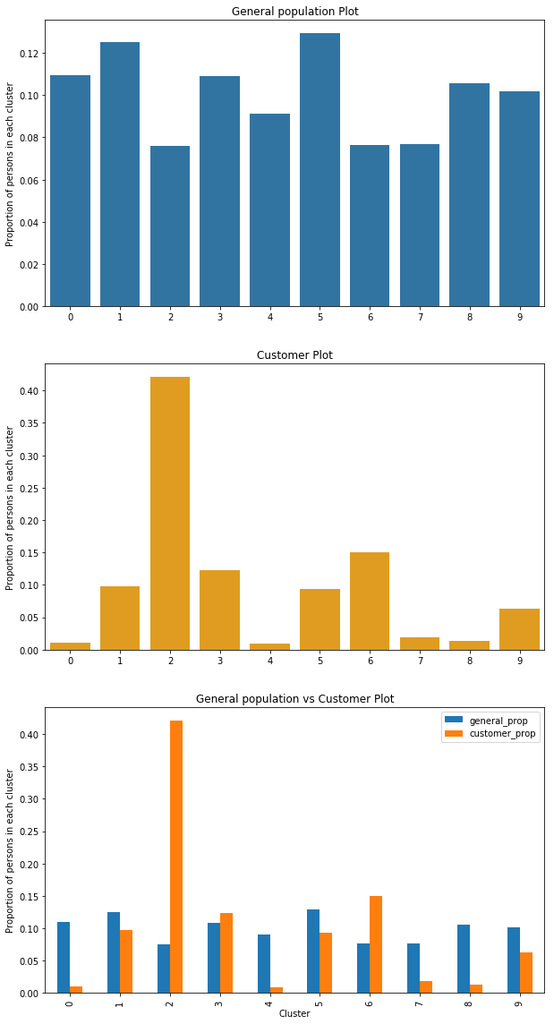

```python
# Plot the result
fig, ax = plt.subplots(3, 1, figsize=(10, 20))
base_color = sns.color_palette()[0]

sns.barplot(data=df_cluster, x='cluster', y='general_prop', color=base_color, ax=ax[0])
ax[0].set_title('General population Plot')
ax[0].set_xlabel('')
ax[0].set_ylabel('Proportion of persons in each cluster')

sns.barplot(data=df_cluster, x='cluster', y='customer_prop', color='orange', ax=ax[1])
ax[1].set_title('Customer Plot')
ax[1].set_xlabel('')
ax[1].set_ylabel('Proportion of persons in each cluster')

df_cluster.plot(x='cluster', y=['general_prop', 'customer_prop'], kind='bar', ax=ax[2])
ax[2].set_title('General population vs Customer Plot')
ax[2].set_xlabel('Cluster')
ax[2].set_ylabel('Proportion of persons in each cluster')
ax[2].legend;
```

I will add a column to df_cluster to show the difference of customer_prop and general_prop: a large positive value means the cluster is overrepresented in the customer data compared to the general population; in contrast, a small negative value means the cluster is underrepresented.

```python
# Add a column to df_cluster
df_cluster['diff'] = df_cluster['customer_prop'] - df_cluster['general_prop']
df_cluster.sort_values('diff', ascending=False)
```

|  | cluster | general_prop | customer_prop | diff |
| --- | --- | --- | --- | --- |
| 2 | 2 | 0.075801 | 0.420816 | 0.345015 |
| 6 | 6 | 0.076220 | 0.150378 | 0.074157 |
| 3 | 3 | 0.108877 | 0.123114 | 0.014238 |
| 1 | 1 | 0.125041 | 0.097919 | -0.027122 |
| 5 | 5 | 0.129240 | 0.093648 | -0.035592 |
| 9 | 9 | 0.101962 | 0.063083 | -0.038878 |
| 7 | 7 | 0.076880 | 0.018558 | -0.058322 |
| 4 | 4 | 0.091073 | 0.009159 | -0.081914 |
| 8 | 8 | 0.105494 | 0.013217 | -0.092277 |
| 0 | 0 | 0.109412 | 0.010108 | -0.099304 |

Based on the figure and the data, we can that **cluster 2 is overrepresented** because 42% customers are assigned to this cluster while only 7% general population are assigned to it. **Cluster 0 is underrepresented** because only 1% customers are assigned to this cluster while 11% general population are assigned to it.

```python
# What kinds of people are part of a cluster that is overrepresented in the
# customer data compared to the general population?

# What kinds of people are part of a cluster that is underrepresented in the
# customer data compared to the general population?

inverse_data = scaler.inverse_transform(pca_20.inverse_transform(kmodel_10.cluster_centers_)).round()
df_inverse = pd.DataFrame(inverse_data, columns=azdias_few.columns)

df_inverse
```

|  | ALTERSKATEGORIE_GROB | ANREDE_KZ | CJT_GESAMTTYP | FINANZ_MINIMALIST | FINANZ_SPARER | FINANZ_VORSORGER | FINANZ_ANLEGER | FINANZ_UNAUFFAELLIGER | FINANZ_HAUSBAUER | FINANZTYP | ... | CAMEO_DEUG_2015_4 | CAMEO_DEUG_2015_5 | CAMEO_DEUG_2015_6 | CAMEO_DEUG_2015_7 | CAMEO_DEUG_2015_8 | CAMEO_DEUG_2015_9 | PRAEGENDE_JUGENDJAHRE_GEN | PRAEGENDE_JUGENDJAHRE_MOVE | CAMEO_INTL_2015_WEALTH | CAMEO_INTL_2015_LIFE |
| --- | --- | --- | --- | --- | --- | --- | --- | --- | --- | --- | --- | --- | --- | --- | --- | --- | --- | --- | --- | --- | --- |
| 0 | 2.0 | 2.0 | 4.0 | 1.0 | 4.0 | 2.0 | 4.0 | 4.0 | 4.0 | 2.0 | ... | 0.0 | 0.0 | 0.0 | 0.0 | 0.0 | 0.0 | 6.0 | 0.0 | 4.0 | 2.0 |
| 1 | 3.0 | 1.0 | 3.0 | 3.0 | 2.0 | 4.0 | 2.0 | 2.0 | 4.0 | 5.0 | ... | 0.0 | 0.0 | 0.0 | 0.0 | 0.0 | 0.0 | 4.0 | 0.0 | 4.0 | 2.0 |
| 2 | 3.0 | 1.0 | 3.0 | 5.0 | 2.0 | 4.0 | 1.0 | 2.0 | 2.0 | 5.0 | ... | 0.0 | 0.0 | 0.0 | 0.0 | 0.0 | 0.0 | 4.0 | 1.0 | 2.0 | 4.0 |
| 3 | 3.0 | 1.0 | 3.0 | 4.0 | 2.0 | 4.0 | 2.0 | 2.0 | 2.0 | 5.0 | ... | 0.0 | 0.0 | 0.0 | 0.0 | 0.0 | 0.0 | 4.0 | 0.0 | 3.0 | 3.0 |
| 4 | 2.0 | 1.0 | 4.0 | 2.0 | 4.0 | 2.0 | 4.0 | 4.0 | 4.0 | 3.0 | ... | 0.0 | 0.0 | 0.0 | 0.0 | 0.0 | 0.0 | 6.0 | 0.0 | 4.0 | 2.0 |
| 5 | 4.0 | 2.0 | 3.0 | 2.0 | 2.0 | 4.0 | 2.0 | 2.0 | 4.0 | 4.0 | ... | 0.0 | 0.0 | 0.0 | 0.0 | 0.0 | 0.0 | 3.0 | 0.0 | 4.0 | 3.0 |
| 6 | 3.0 | 2.0 | 3.0 | 4.0 | 2.0 | 4.0 | 2.0 | 2.0 | 2.0 | 4.0 | ... | 0.0 | 0.0 | 0.0 | 0.0 | 0.0 | 0.0 | 4.0 | 1.0 | 2.0 | 4.0 |
| 7 | 2.0 | 1.0 | 4.0 | 3.0 | 4.0 | 2.0 | 4.0 | 4.0 | 2.0 | 3.0 | ... | 0.0 | 0.0 | 0.0 | 0.0 | 0.0 | 0.0 | 6.0 | 0.0 | 2.0 | 3.0 |
| 8 | 2.0 | 2.0 | 4.0 | 2.0 | 4.0 | 2.0 | 4.0 | 4.0 | 3.0 | 2.0 | ... | 0.0 | 0.0 | 0.0 | 0.0 | 0.0 | 0.0 | 6.0 | 0.0 | 3.0 | 3.0 |
| 9 | 4.0 | 2.0 | 3.0 | 4.0 | 2.0 | 4.0 | 3.0 | 2.0 | 3.0 | 4.0 | ... | 0.0 | 0.0 | 0.0 | 0.0 | 0.0 | 0.0 | 4.0 | 0.0 | 3.0 | 3.0 |

10 rows × 84 columns

```python
df_inverse.iloc[2,:]
```

```
ALTERSKATEGORIE_GROB            3.0
ANREDE_KZ                       1.0
CJT_GESAMTTYP                   3.0
FINANZ_MINIMALIST               5.0
FINANZ_SPARER                   2.0
FINANZ_VORSORGER                4.0
FINANZ_ANLEGER                  1.0
FINANZ_UNAUFFAELLIGER           2.0
FINANZ_HAUSBAUER                2.0
FINANZTYP                       5.0
GFK_URLAUBERTYP                 6.0
GREEN_AVANTGARDE                1.0
HEALTH_TYP                      2.0
LP_FAMILIE_FEIN                 5.0
LP_FAMILIE_GROB                 3.0
LP_STATUS_FEIN                  9.0
LP_STATUS_GROB                  4.0
NATIONALITAET_KZ                1.0
RETOURTYP_BK_S                  4.0
SEMIO_SOZ                       5.0
SEMIO_FAM                       5.0
SEMIO_REL                       4.0
SEMIO_MAT                       4.0
SEMIO_VERT                      6.0
SEMIO_LUST                      5.0
SEMIO_ERL                       4.0
SEMIO_KULT                      5.0
SEMIO_RAT                       3.0
SEMIO_KRIT                      3.0
SEMIO_DOM                       3.0
                              ...
EWDICHTE                        4.0
INNENSTADT                      5.0
GEBAEUDETYP_RASTER              4.0
KKK                             2.0
MOBI_REGIO                      4.0
ONLINE_AFFINITAET               3.0
REGIOTYP                        3.0
KBA13_ANZAHL_PKW              705.0
PLZ8_ANTG1                      3.0
PLZ8_ANTG2                      3.0
PLZ8_ANTG3                      1.0
PLZ8_ANTG4                      0.0
PLZ8_HHZ                        4.0
PLZ8_GBZ                        4.0
ARBEIT                          3.0
ORTSGR_KLS9                     5.0
RELAT_AB                        3.0
CAMEO_DEUG_2015_1               0.0
CAMEO_DEUG_2015_2               0.0
CAMEO_DEUG_2015_3               0.0
CAMEO_DEUG_2015_4               0.0
CAMEO_DEUG_2015_5               0.0
CAMEO_DEUG_2015_6               0.0
CAMEO_DEUG_2015_7               0.0
CAMEO_DEUG_2015_8               0.0
CAMEO_DEUG_2015_9               0.0
PRAEGENDE_JUGENDJAHRE_GEN       4.0
PRAEGENDE_JUGENDJAHRE_MOVE      1.0
CAMEO_INTL_2015_WEALTH          2.0
CAMEO_INTL_2015_LIFE            4.0
Name: 2, Length: 84, dtype: float64
```

```python
df_inverse.iloc[0,:]
```

```
ALTERSKATEGORIE_GROB            2.0
ANREDE_KZ                       2.0
CJT_GESAMTTYP                   4.0
FINANZ_MINIMALIST               1.0
FINANZ_SPARER                   4.0
FINANZ_VORSORGER                2.0
FINANZ_ANLEGER                  4.0
FINANZ_UNAUFFAELLIGER           4.0
FINANZ_HAUSBAUER                4.0
FINANZTYP                       2.0
GFK_URLAUBERTYP                 9.0
GREEN_AVANTGARDE                0.0
HEALTH_TYP                      2.0
LP_FAMILIE_FEIN                 3.0
LP_FAMILIE_GROB                 2.0
LP_STATUS_FEIN                  2.0
LP_STATUS_GROB                  1.0
NATIONALITAET_KZ                1.0
RETOURTYP_BK_S                  3.0
SEMIO_SOZ                       3.0
SEMIO_FAM                       4.0
SEMIO_REL                       5.0
SEMIO_MAT                       5.0
SEMIO_VERT                      2.0
SEMIO_LUST                      3.0
SEMIO_ERL                       4.0
SEMIO_KULT                      4.0
SEMIO_RAT                       6.0
SEMIO_KRIT                      6.0
SEMIO_DOM                       6.0
                              ...
EWDICHTE                        5.0
INNENSTADT                      3.0
GEBAEUDETYP_RASTER              3.0
KKK                             3.0
MOBI_REGIO                      2.0
ONLINE_AFFINITAET               3.0
REGIOTYP                        5.0
KBA13_ANZAHL_PKW              536.0
PLZ8_ANTG1                      1.0
PLZ8_ANTG2                      3.0
PLZ8_ANTG3                      2.0
PLZ8_ANTG4                      1.0
PLZ8_HHZ                        4.0
PLZ8_GBZ                        3.0
ARBEIT                          4.0
ORTSGR_KLS9                     7.0
RELAT_AB                        4.0
CAMEO_DEUG_2015_1               0.0
CAMEO_DEUG_2015_2               0.0
CAMEO_DEUG_2015_3               0.0
CAMEO_DEUG_2015_4               0.0
CAMEO_DEUG_2015_5               0.0
CAMEO_DEUG_2015_6               0.0
CAMEO_DEUG_2015_7               0.0
CAMEO_DEUG_2015_8               0.0
CAMEO_DEUG_2015_9               0.0
PRAEGENDE_JUGENDJAHRE_GEN       6.0
PRAEGENDE_JUGENDJAHRE_MOVE      0.0
CAMEO_INTL_2015_WEALTH          4.0
CAMEO_INTL_2015_LIFE            2.0
Name: 0, Length: 84, dtype: float64
```

### Discussion 3.3: Compare Customer Data to Demographics Data

The segments of the population that are relatively popular with the mail-order company are those from cluster 2. They are **46-60 years old, male, upper middle class, prosperous households, house owners, advertisinginterested store-shoppers, with high financial interest, with low socially-minded and low dreamful personality, etc**.

The segments of the population that are relatively unpopular with the mail-order company are those from cluster 0. They are **30-45 years old, female, lower middle class, less affluent households, advertisinginterested online-shoppers, with low financial interest, with high socially-minded and high dreamful personality, etc**.